# R Notebook

# Preamble

## Call libraries

```r
library(tidyverse)
library(janitor)
library(here)
library(lubridate)
library(ggthemes)
```

# Number of cancer cases - Data Wrangling

## View cancer incidence data

**Incidence by Health Board**

`https://www.opendata.nhs.scot/dataset/c2c59eb1-3aff-48d2-9e9c-60ca8605431d/resource/3aef16b7-8af6-4ce0-a90b-8a29d6870014/download/opendata_inc9620_hb.csv`

**Note:** I had to use the following command and arguments to read the csv file:

```r
incidence <- read_delim(here("raw_data/opendata_inc9620_hb.csv"), delim = "\t") %>%
  clean_names()
glimpse(incidence)
```

```
Rows: 47,600
Columns: 23
$ hb                                       <chr> "S08000015", "S08000015", "S08000015", "S08000015", "S08000015", "S08000015", "S0800~
$ cancer_site_icd10code                    <chr> "C00-C97, excluding C44", "C00-C97, excluding C44", "C00-C97, excluding C44", "C00-C~
$ cancer_site                              <chr> "All cancer types", "All cancer types", "All cancer types", "All cancer types", "All~
$ sex                                      <chr> "All", "All", "All", "All", "All", "All", "All", "All", "All", "All", "All", "All", ~
$ sex_qf                                   <chr> "d", "d", "d", "d", "d", "d", "d", "d", "d", "d", "d", "d", "d", "d", "d", "d", "d",~
$ year                                     <dbl> 1996, 1997, 1998, 1999, 2000, 2001, 2002, 2003, 2004, 2005, 2006, 2007, 2008, 2009, ~
$ incidences_all_ages                      <dbl> 2014, 2019, 1958, 1966, 1942, 1990, 2043, 2142, 2184, 2125, 2110, 2195, 2308, 2346, ~
$ crude_rate                               <dbl> 539.7293, 541.6499, 526.6414, 530.5484, 526.6155, 540.3351, 555.9184, 582.5243, 592.~
$ crude_rate_lower95pc_confidence_interval <dbl> 516.4123, 518.2786, 503.5703, 507.3529, 503.4518, 516.8531, 532.0711, 558.1138, 567.~
$ crude_rate_upper95pc_confidence_interval <dbl> 563.8279, 565.8035, 550.4969, 554.5308, 550.5701, 564.6089, 580.5590, 607.7276, 617.~
$ easr                                     <dbl> 645.8993, 653.6445, 621.0194, 628.6583, 611.9952, 618.7622, 645.9641, 651.5652, 652.~
$ easr_lower95pc_confidence_interval       <chr> "616.8179626", "623.8631686", "592.4901439", "599.7664282", "583.8275633", "590.6154~
$ easr_lower95pc_confidence_interval_qf    <chr> " ", " ", " ", " ", " ", " ", " ", " ", " ", " ", " ", " ", " ", " ", " ", " ", " ",~
$ easr_upper95pc_confidence_interval       <chr> "675.6410359", "684.1103633", "650.2101051", "658.2201666", "640.817193", "647.55489~
$ easr_upper95pc_confidence_interval_qf    <chr> " ", " ", " ", " ", " ", " ", " ", " ", " ", " ", " ", " ", " ", " ", " ", " ", " ",~
$ wasr                                     <dbl> 303.4057, 295.3486, 286.0872, 288.1310, 281.6776, 282.4215, 283.8874, 297.1144, 299.~
$ wasr_lower95pc_confidence_interval       <chr> "289.1865282", "281.519918", "272.4115417", "274.3408264", "267.9613079", "268.95786~
$ wasr_lower95pc_confidence_interval_qf    <chr> " ", " ", " ", " ", " ", " ", " ", " ", " ", " ", " ", " ", " ", " ", " ", " ", " ",~
$ wasr_upper95pc_confidence_interval       <chr> "317.9614182", "309.5041116", "300.0929871", "302.2546486", "295.7314805", "296.2093~
$ wasr_upper95pc_confidence_interval_qf    <chr> " ", " ", " ", " ", " ", " ", " ", " ", " ", " ", " ", " ", " ", " ", " ", " ", " ",~
$ standardised_incidence_ratio             <dbl> 96.00872, 99.95748, 98.52079, 98.58895, 96.14347, 98.21248, 98.53026, 101.62526, 100~
$ sir_lower95pc_confidence_interval        <dbl> 91.86101, 95.64447, 94.20479, 94.27867, 91.91450, 93.94434, 94.30361, 97.36669, 96.7~
$ sir_upper95pc_confidence_interval        <dbl> 100.29544, 104.41486, 102.98353, 103.04548, 100.51683, 102.62455, 102.89754, 106.022~
```

### Check incidence data for NA values

```r
incidence  %>%
  summarise(across(.cols = everything(),
                   .fns = ~sum(is.na(.x))))
```

| hb | cancer_site_icd10code | cancer_site | sex | sex_qf | year | incidences_all_ages | crude_rate | crude_rate_lower95pc_confidence_interval | crude_rate_upper95pc_confidence_interval | easr | easr_lower95pc_confidence_interval | easr_lower95pc_confidence_interval_qf | easr_upper95pc_confidence_interval | easr_upper95pc_confidence_interval_qf | wasr | wasr_lower95pc_confidence_interval | wasr_lower95pc_confidence_interval_qf | wasr_upper95pc_confidence_interval | wasr_upper95pc_confidence_interval_qf | standardised_incidence_ratio | sir_lower95pc_confidence_interval | sir_upper95pc_confidence_interval |
| --- | --- | --- | --- | --- | --- | --- | --- | --- | --- | --- | --- | --- | --- | --- | --- | --- | --- | --- | --- | --- | --- | --- |
| 0 | 0 | 0 | 0 | 0 | 0 | 0 | 0 | 0 | 0 | 0 | 0 | 0 | 0 | 0 | 0 | 0 | 0 | 0 | 0 | 0 | 0 | 0 |

```r
NA
```

No missing values!!!

## View 5 year summary cancer incidence data

**5 Year Summary of Incidence by Health Board**

`https://www.opendata.nhs.scot/dataset/c2c59eb1-3aff-48d2-9e9c-60ca8605431d/resource/e8d33b2b-1fb2-4d59-ad21-20fa2f76d9d5/download/opendata_inc1620comb_hb.csv`

**Note:** I had to use the following command and arguments to read the csv file:

```r
incidence_5_year_summary <- read_delim(here("raw_data/opendata_inc1620comb_hb.csv"), delim = "\t") %>%
  clean_names()
glimpse(incidence_5_year_summary)
```

```
Rows: 1,632
Columns: 59
$ hb                                       <chr> "S08000015", "S08000015", "S08000015", "S08000015", "S08000015", "S08000015", "S0800~
$ cancer_site_icd10code                    <chr> "C00-C97, excluding C44", "C00-C97, excluding C44", "C00-C97, excluding C44", "C67",~
$ cancer_site                              <chr> "All cancer types", "All cancer types", "All cancer types", "Bladder", "Bladder", "B~
$ sex                                      <chr> "All", "Male", "Female", "All", "Male", "Female", "All", "Male", "Female", "All", "M~
$ sex_qf                                   <chr> "d", " ", " ", "d", " ", " ", "d", " ", " ", "d", " ", " ", "d", " ", " ", "d", " ",~
$ year                                     <chr> "2016-2020", "2016-2020", "2016-2020", "2016-2020", "2016-2020", "2016-2020", "2016-~
$ incidences_age_under5                    <dbl> 11, 8, 3, 0, 0, 0, 0, 0, 0, 2, 1, 1, 2, 1, 1, 1, 1, 0, 1, 1, 0, 1, 1, 0, 2, 2, 0, 0,~
$ incidences_age5to9                       <dbl> 12, 7, 5, 0, 0, 0, 0, 0, 0, 2, 1, 1, 2, 1, 1, 4, 2, 2, 4, 2, 2, 1, 0, 1, 5, 2, 3, 0,~
$ incidences_age10to14                     <dbl> 13, 2, 11, 0, 0, 0, 1, 0, 1, 1, 0, 1, 0, 0, 0, 3, 1, 2, 3, 1, 2, 1, 0, 1, 4, 1, 3, 0~
$ incidences_age15to19                     <dbl> 24, 13, 11, 1, 1, 0, 2, 0, 2, 3, 0, 3, 1, 0, 1, 3, 2, 1, 3, 2, 1, 2, 1, 1, 5, 3, 2, ~
$ incidences_age20to24                     <dbl> 26, 8, 18, 0, 0, 0, 0, 0, 0, 3, 0, 3, 3, 0, 3, 1, 1, 0, 1, 1, 0, 2, 2, 0, 3, 3, 0, 2~
$ incidences_age25to29                     <dbl> 61, 23, 38, 0, 0, 0, 0, 0, 0, 0, 0, 0, 0, 0, 0, 4, 2, 2, 4, 2, 2, 5, 1, 4, 9, 3, 6, ~
$ incidences_age30to34                     <dbl> 94, 30, 64, 1, 1, 0, 0, 0, 0, 1, 0, 1, 1, 0, 1, 6, 1, 5, 6, 1, 5, 5, 1, 4, 11, 2, 9,~
```

[output cut: 46 more lines]

### Check 5 year summary incidence data for NA values

```r
incidence_5_year_summary  %>%
  summarise(across(.cols = everything(),
                   .fns = ~sum(is.na(.x))))
```

| hb | cancer_site_icd10code | cancer_site | sex | sex_qf | year | incidences_age_under5 | incidences_age5to9 | incidences_age10to14 | incidences_age15to19 | incidences_age20to24 | incidences_age25to29 | incidences_age30to34 | incidences_age35to39 | incidences_age40to44 | incidences_age45to49 | incidences_age50to54 | incidences_age55to59 | incidences_age60to64 | incidences_age65to69 | incidences_age70to74 | incidences_age75to79 | incidences_age80to84 | incidences_age85and_over | incidences_all_ages | incidence_rate_age_under5 | incidence_rate_age5to9 | incidence_rate_age10to14 | incidence_rate_age15to19 | incidence_rate_age20to24 | … |
| --- | --- | --- | --- | --- | --- | --- | --- | --- | --- | --- | --- | --- | --- | --- | --- | --- | --- | --- | --- | --- | --- | --- | --- | --- | --- | --- | --- | --- | --- | --- |
| 0 | 0 | 0 | 0 | 0 | 0 | 0 | 0 | 0 | 0 | 0 | 0 | 0 | 0 | 0 | 0 | 0 | 0 | 0 | 0 | 0 | 0 | 0 | 0 | 0 | 0 | 0 | 0 | 0 | 0 | … |

```r
NA
```

No missing values!!!

### What are the distinct cancer values in the incidence data ?

Check the diagnosed cancer site

```r
incidence  %>%
  distinct(cancer_site)
```

| cancer_site |
| --- |
| All cancer types |
| Bladder |
| Bone and articular cartilage |
| Bone and connective tissue |
| Connective tissue |
| Malignant brain cancer |
| Malig brain ca (incl pit. gland, cranio. duct, pineal gland) |
| Non-malig brain ca (incl pit.gland,cranio.duct,pineal gland) |
| All brain and CNS tumours (malignant and non-malignant) |
| Breast |

[output cut: 42 more lines]

### What are the distinct cancer values in the 5 year summary incidence data ?

Check the diagnosed cancer site

```r
incidence_5_year_summary  %>%
  distinct(cancer_site)
```

| cancer_site |
| --- |
| All cancer types |
| Bladder |
| Bone and articular cartilage |
| Bone and connective tissue |
| Connective tissue |
| Malignant brain cancer |
| Malig brain ca (incl pit. gland, cranio. duct, pineal gland) |
| Non-malig brain ca (incl pit.gland,cranio.duct,pineal gland) |
| All brain and CNS tumours (malignant and non-malignant) |
| Breast |

[output cut: 42 more lines]

## View health board data

**Health Board 2014 - Health Board 2019**

`https://www.opendata.nhs.scot/dataset/9f942fdb-e59e-44f5-b534-d6e17229cc7b/resource/652ff726-e676-4a20-abda-435b98dd7bdc/download/hb14_hb19.csv`

```r
health_board_labels <- read_csv(here("raw_data/geography_codes_and_labels_hb2014_01042019.csv")) %>%
  clean_names()
glimpse(health_board_labels)
```

```
Rows: 18
Columns: 5
$ hb               <chr> "S08000015", "S08000016", "S08000017", "S08000018", "S08000019", "S08000020", "S08000021", "S08000022", "S08~
$ hb_name          <chr> "NHS Ayrshire and Arran", "NHS Borders", "NHS Dumfries and Galloway", "NHS Fife", "NHS Forth Valley", "NHS G~
$ hb_date_enacted  <dbl> 20140401, 20140401, 20140401, 20140401, 20140401, 20140401, 20140401, 20140401, 20140401, 20140401, 20140401~
$ hb_date_archived <dbl> NA, NA, NA, 20180201, NA, NA, 20190331, NA, 20190331, NA, NA, NA, 20180201, NA, NA, NA, NA, NA
$ country          <chr> "S92000003", "S92000003", "S92000003", "S92000003", "S92000003", "S92000003", "S92000003", "S92000003", "S92~
```

### View all HB values

```r
health_board_labels %>%
  distinct(hb, hb_name, hb_date_enacted)
```

| hb | hb_name | hb_date_enacted |
| --- | --- | --- |
| S08000015 | NHS Ayrshire and Arran | 20140401 |
| S08000016 | NHS Borders | 20140401 |
| S08000017 | NHS Dumfries and Galloway | 20140401 |
| S08000018 | NHS Fife | 20140401 |
| S08000019 | NHS Forth Valley | 20140401 |
| S08000020 | NHS Grampian | 20140401 |
| S08000021 | NHS Greater Glasgow and Clyde | 20140401 |
| S08000022 | NHS Highland | 20140401 |
| S08000023 | NHS Lanarkshire | 20140401 |
| S08000024 | NHS Lothian | 20140401 |

[output cut: 8 more lines]

### Remove junk

```r
health_board_labels <- health_board_labels %>%
  select(hb, hb_name)


glimpse(health_board_labels)
```

```
Rows: 18
Columns: 2
$ hb      <chr> "S08000015", "S08000016", "S08000017", "S08000018", "S08000019", "S08000020", "S08000021", "S08000022", "S08000023", ~
$ hb_name <chr> "NHS Ayrshire and Arran", "NHS Borders", "NHS Dumfries and Galloway", "NHS Fife", "NHS Forth Valley", "NHS Grampian",~
```

## View Custom Grouped Geographies

**Grouped geographies used by ISD Scotland for bespoke analysis or to aid the availability of data which usually would have to be suppressed**

`https://www.opendata.nhs.scot/dataset/65402d20-f0f1-4cee-a4f9-a960ca560444/resource/8f0c3067-7b10-44c6-af36-37f87a9e6efa/download/grouped-geography.csv`

```r
grouped_geography_labels <- read_csv(here("raw_data/grouped-geography.csv")) %>%
  clean_names()
glimpse(grouped_geography_labels)
```

```
Rows: 1
Columns: 3
$ grouped_geography         <chr> "GR0800001"
$ grouped_geography_name    <chr> "NHS Island Boards"
$ grouped_geography_details <chr> "Combined Boards for NHS Orkney, NHS Shetland and NHS Western Isles"
```

### Remove junk

```r
grouped_geography_labels <- grouped_geography_labels %>%
  select(grouped_geography, grouped_geography_name)


glimpse(grouped_geography_labels)
```

```
Rows: 1
Columns: 2
$ grouped_geography      <chr> "GR0800001"
$ grouped_geography_name <chr> "NHS Island Boards"
```

# Join tables

## Join 5 year summary incidence & health board & custom grouped geographies

```r
incidence_5_year_summary <- incidence_5_year_summary %>%
  left_join(health_board_labels, "hb")

incidence_5_year_summary <- incidence_5_year_summary %>%
  left_join(grouped_geography_labels, by = c("hb" = "grouped_geography"))

glimpse(incidence_5_year_summary)
```

```
Rows: 1,632
Columns: 61
$ hb                                       <chr> "S08000015", "S08000015", "S08000015", "S08000015", "S08000015", "S08000015", "S0800~
$ cancer_site_icd10code                    <chr> "C00-C97, excluding C44", "C00-C97, excluding C44", "C00-C97, excluding C44", "C67",~
$ cancer_site                              <chr> "All cancer types", "All cancer types", "All cancer types", "Bladder", "Bladder", "B~
$ sex                                      <chr> "All", "Male", "Female", "All", "Male", "Female", "All", "Male", "Female", "All", "M~
$ sex_qf                                   <chr> "d", " ", " ", "d", " ", " ", "d", " ", " ", "d", " ", " ", "d", " ", " ", "d", " ",~
$ year                                     <chr> "2016-2020", "2016-2020", "2016-2020", "2016-2020", "2016-2020", "2016-2020", "2016-~
$ incidences_age_under5                    <dbl> 11, 8, 3, 0, 0, 0, 0, 0, 0, 2, 1, 1, 2, 1, 1, 1, 1, 0, 1, 1, 0, 1, 1, 0, 2, 2, 0, 0,~
$ incidences_age5to9                       <dbl> 12, 7, 5, 0, 0, 0, 0, 0, 0, 2, 1, 1, 2, 1, 1, 4, 2, 2, 4, 2, 2, 1, 0, 1, 5, 2, 3, 0,~
$ incidences_age10to14                     <dbl> 13, 2, 11, 0, 0, 0, 1, 0, 1, 1, 0, 1, 0, 0, 0, 3, 1, 2, 3, 1, 2, 1, 0, 1, 4, 1, 3, 0~
$ incidences_age15to19                     <dbl> 24, 13, 11, 1, 1, 0, 2, 0, 2, 3, 0, 3, 1, 0, 1, 3, 2, 1, 3, 2, 1, 2, 1, 1, 5, 3, 2, ~
$ incidences_age20to24                     <dbl> 26, 8, 18, 0, 0, 0, 0, 0, 0, 3, 0, 3, 3, 0, 3, 1, 1, 0, 1, 1, 0, 2, 2, 0, 3, 3, 0, 2~
$ incidences_age25to29                     <dbl> 61, 23, 38, 0, 0, 0, 0, 0, 0, 0, 0, 0, 0, 0, 0, 4, 2, 2, 4, 2, 2, 5, 1, 4, 9, 3, 6, ~
$ incidences_age30to34                     <dbl> 94, 30, 64, 1, 1, 0, 0, 0, 0, 1, 0, 1, 1, 0, 1, 6, 1, 5, 6, 1, 5, 5, 1, 4, 11, 2, 9,~
```

[output cut: 48 more lines]

### Concatenate `hb_name` and `grouped_geography_name` in a single column called `hb_name`

```r
incidence_5_year_summary <- incidence_5_year_summary %>%
  mutate(hb_name = if_else(!is.na(hb_name), hb_name, grouped_geography_name)) %>%
  select(-grouped_geography_name)

glimpse(incidence_5_year_summary)
```

```
Rows: 1,632
Columns: 60
$ hb                                       <chr> "S08000015", "S08000015", "S08000015", "S08000015", "S08000015", "S08000015", "S0800~
$ cancer_site_icd10code                    <chr> "C00-C97, excluding C44", "C00-C97, excluding C44", "C00-C97, excluding C44", "C67",~
$ cancer_site                              <chr> "All cancer types", "All cancer types", "All cancer types", "Bladder", "Bladder", "B~
$ sex                                      <chr> "All", "Male", "Female", "All", "Male", "Female", "All", "Male", "Female", "All", "M~
$ sex_qf                                   <chr> "d", " ", " ", "d", " ", " ", "d", " ", " ", "d", " ", " ", "d", " ", " ", "d", " ",~
$ year                                     <chr> "2016-2020", "2016-2020", "2016-2020", "2016-2020", "2016-2020", "2016-2020", "2016-~
$ incidences_age_under5                    <dbl> 11, 8, 3, 0, 0, 0, 0, 0, 0, 2, 1, 1, 2, 1, 1, 1, 1, 0, 1, 1, 0, 1, 1, 0, 2, 2, 0, 0,~
$ incidences_age5to9                       <dbl> 12, 7, 5, 0, 0, 0, 0, 0, 0, 2, 1, 1, 2, 1, 1, 4, 2, 2, 4, 2, 2, 1, 0, 1, 5, 2, 3, 0,~
$ incidences_age10to14                     <dbl> 13, 2, 11, 0, 0, 0, 1, 0, 1, 1, 0, 1, 0, 0, 0, 3, 1, 2, 3, 1, 2, 1, 0, 1, 4, 1, 3, 0~
$ incidences_age15to19                     <dbl> 24, 13, 11, 1, 1, 0, 2, 0, 2, 3, 0, 3, 1, 0, 1, 3, 2, 1, 3, 2, 1, 2, 1, 1, 5, 3, 2, ~
$ incidences_age20to24                     <dbl> 26, 8, 18, 0, 0, 0, 0, 0, 0, 3, 0, 3, 3, 0, 3, 1, 1, 0, 1, 1, 0, 2, 2, 0, 3, 3, 0, 2~
$ incidences_age25to29                     <dbl> 61, 23, 38, 0, 0, 0, 0, 0, 0, 0, 0, 0, 0, 0, 0, 4, 2, 2, 4, 2, 2, 5, 1, 4, 9, 3, 6, ~
$ incidences_age30to34                     <dbl> 94, 30, 64, 1, 1, 0, 0, 0, 0, 1, 0, 1, 1, 0, 1, 6, 1, 5, 6, 1, 5, 5, 1, 4, 11, 2, 9,~
```

[output cut: 47 more lines]

```r
incidence_5_year_summary  %>%
  summarise(across(.cols = everything(),
                   .fns = ~sum(is.na(.x))))
```

| hb | cancer_site_icd10code | cancer_site | sex | sex_qf | year | incidences_age_under5 | incidences_age5to9 | incidences_age10to14 | incidences_age15to19 | incidences_age20to24 | incidences_age25to29 | incidences_age30to34 | incidences_age35to39 | incidences_age40to44 | incidences_age45to49 | incidences_age50to54 | incidences_age55to59 | incidences_age60to64 | incidences_age65to69 | incidences_age70to74 | incidences_age75to79 | incidences_age80to84 | incidences_age85and_over | incidences_all_ages | incidence_rate_age_under5 | incidence_rate_age5to9 | incidence_rate_age10to14 | incidence_rate_age15to19 | incidence_rate_age20to24 | … |
| --- | --- | --- | --- | --- | --- | --- | --- | --- | --- | --- | --- | --- | --- | --- | --- | --- | --- | --- | --- | --- | --- | --- | --- | --- | --- | --- | --- | --- | --- | --- |
| 0 | 0 | 0 | 0 | 0 | 0 | 0 | 0 | 0 | 0 | 0 | 0 | 0 | 0 | 0 | 0 | 0 | 0 | 0 | 0 | 0 | 0 | 0 | 0 | 0 | 0 | 0 | 0 | 0 | 0 | … |

```r
NA
```

## Join incidence & health board

```r
incidence <- incidence %>%
  left_join(health_board_labels, "hb")

incidence <- incidence %>%
  left_join(grouped_geography_labels, by = c("hb" = "grouped_geography"))


glimpse(incidence)
```

```
Rows: 47,600
Columns: 25
$ hb                                       <chr> "S08000015", "S08000015", "S08000015", "S08000015", "S08000015", "S08000015", "S0800~
$ cancer_site_icd10code                    <chr> "C00-C97, excluding C44", "C00-C97, excluding C44", "C00-C97, excluding C44", "C00-C~
$ cancer_site                              <chr> "All cancer types", "All cancer types", "All cancer types", "All cancer types", "All~
$ sex                                      <chr> "All", "All", "All", "All", "All", "All", "All", "All", "All", "All", "All", "All", ~
$ sex_qf                                   <chr> "d", "d", "d", "d", "d", "d", "d", "d", "d", "d", "d", "d", "d", "d", "d", "d", "d",~
$ year                                     <dbl> 1996, 1997, 1998, 1999, 2000, 2001, 2002, 2003, 2004, 2005, 2006, 2007, 2008, 2009, ~
$ incidences_all_ages                      <dbl> 2014, 2019, 1958, 1966, 1942, 1990, 2043, 2142, 2184, 2125, 2110, 2195, 2308, 2346, ~
$ crude_rate                               <dbl> 539.7293, 541.6499, 526.6414, 530.5484, 526.6155, 540.3351, 555.9184, 582.5243, 592.~
$ crude_rate_lower95pc_confidence_interval <dbl> 516.4123, 518.2786, 503.5703, 507.3529, 503.4518, 516.8531, 532.0711, 558.1138, 567.~
$ crude_rate_upper95pc_confidence_interval <dbl> 563.8279, 565.8035, 550.4969, 554.5308, 550.5701, 564.6089, 580.5590, 607.7276, 617.~
$ easr                                     <dbl> 645.8993, 653.6445, 621.0194, 628.6583, 611.9952, 618.7622, 645.9641, 651.5652, 652.~
$ easr_lower95pc_confidence_interval       <chr> "616.8179626", "623.8631686", "592.4901439", "599.7664282", "583.8275633", "590.6154~
$ easr_lower95pc_confidence_interval_qf    <chr> " ", " ", " ", " ", " ", " ", " ", " ", " ", " ", " ", " ", " ", " ", " ", " ", " ",~
$ easr_upper95pc_confidence_interval       <chr> "675.6410359", "684.1103633", "650.2101051", "658.2201666", "640.817193", "647.55489~
$ easr_upper95pc_confidence_interval_qf    <chr> " ", " ", " ", " ", " ", " ", " ", " ", " ", " ", " ", " ", " ", " ", " ", " ", " ",~
$ wasr                                     <dbl> 303.4057, 295.3486, 286.0872, 288.1310, 281.6776, 282.4215, 283.8874, 297.1144, 299.~
$ wasr_lower95pc_confidence_interval       <chr> "289.1865282", "281.519918", "272.4115417", "274.3408264", "267.9613079", "268.95786~
$ wasr_lower95pc_confidence_interval_qf    <chr> " ", " ", " ", " ", " ", " ", " ", " ", " ", " ", " ", " ", " ", " ", " ", " ", " ",~
$ wasr_upper95pc_confidence_interval       <chr> "317.9614182", "309.5041116", "300.0929871", "302.2546486", "295.7314805", "296.2093~
$ wasr_upper95pc_confidence_interval_qf    <chr> " ", " ", " ", " ", " ", " ", " ", " ", " ", " ", " ", " ", " ", " ", " ", " ", " ",~
$ standardised_incidence_ratio             <dbl> 96.00872, 99.95748, 98.52079, 98.58895, 96.14347, 98.21248, 98.53026, 101.62526, 100~
$ sir_lower95pc_confidence_interval        <dbl> 91.86101, 95.64447, 94.20479, 94.27867, 91.91450, 93.94434, 94.30361, 97.36669, 96.7~
$ sir_upper95pc_confidence_interval        <dbl> 100.29544, 104.41486, 102.98353, 103.04548, 100.51683, 102.62455, 102.89754, 106.022~
$ hb_name                                  <chr> "NHS Ayrshire and Arran", "NHS Ayrshire and Arran", "NHS Ayrshire and Arran", "NHS A~
$ grouped_geography_name                   <chr> NA, NA, NA, NA, NA, NA, NA, NA, NA, NA, NA, NA, NA, NA, NA, NA, NA, NA, NA, NA, NA, ~
```

### Concatenate `hb_name` and `grouped_geography_name` in a single column called `hb_name`

```r
incidence <- incidence %>%
  mutate(hb_name = if_else(!is.na(hb_name), hb_name, grouped_geography_name)) %>%
  select(-grouped_geography_name)

glimpse(incidence_5_year_summary)
```

```
Rows: 1,632
Columns: 60
$ hb                                       <chr> "S08000015", "S08000015", "S08000015", "S08000015", "S08000015", "S08000015", "S0800~
$ cancer_site_icd10code                    <chr> "C00-C97, excluding C44", "C00-C97, excluding C44", "C00-C97, excluding C44", "C67",~
$ cancer_site                              <chr> "All cancer types", "All cancer types", "All cancer types", "Bladder", "Bladder", "B~
$ sex                                      <chr> "All", "Male", "Female", "All", "Male", "Female", "All", "Male", "Female", "All", "M~
$ sex_qf                                   <chr> "d", " ", " ", "d", " ", " ", "d", " ", " ", "d", " ", " ", "d", " ", " ", "d", " ",~
$ year                                     <chr> "2016-2020", "2016-2020", "2016-2020", "2016-2020", "2016-2020", "2016-2020", "2016-~
$ incidences_age_under5                    <dbl> 11, 8, 3, 0, 0, 0, 0, 0, 0, 2, 1, 1, 2, 1, 1, 1, 1, 0, 1, 1, 0, 1, 1, 0, 2, 2, 0, 0,~
$ incidences_age5to9                       <dbl> 12, 7, 5, 0, 0, 0, 0, 0, 0, 2, 1, 1, 2, 1, 1, 4, 2, 2, 4, 2, 2, 1, 0, 1, 5, 2, 3, 0,~
$ incidences_age10to14                     <dbl> 13, 2, 11, 0, 0, 0, 1, 0, 1, 1, 0, 1, 0, 0, 0, 3, 1, 2, 3, 1, 2, 1, 0, 1, 4, 1, 3, 0~
$ incidences_age15to19                     <dbl> 24, 13, 11, 1, 1, 0, 2, 0, 2, 3, 0, 3, 1, 0, 1, 3, 2, 1, 3, 2, 1, 2, 1, 1, 5, 3, 2, ~
$ incidences_age20to24                     <dbl> 26, 8, 18, 0, 0, 0, 0, 0, 0, 3, 0, 3, 3, 0, 3, 1, 1, 0, 1, 1, 0, 2, 2, 0, 3, 3, 0, 2~
$ incidences_age25to29                     <dbl> 61, 23, 38, 0, 0, 0, 0, 0, 0, 0, 0, 0, 0, 0, 0, 4, 2, 2, 4, 2, 2, 5, 1, 4, 9, 3, 6, ~
$ incidences_age30to34                     <dbl> 94, 30, 64, 1, 1, 0, 0, 0, 0, 1, 0, 1, 1, 0, 1, 6, 1, 5, 6, 1, 5, 5, 1, 4, 11, 2, 9,~
```

[output cut: 47 more lines]

```r
incidence  %>%
  summarise(across(.cols = everything(),
                   .fns = ~sum(is.na(.x))))
```

| hb | cancer_site_icd10code | cancer_site | sex | sex_qf | year | incidences_all_ages | crude_rate | crude_rate_lower95pc_confidence_interval | crude_rate_upper95pc_confidence_interval | easr | easr_lower95pc_confidence_interval | easr_lower95pc_confidence_interval_qf | easr_upper95pc_confidence_interval | easr_upper95pc_confidence_interval_qf | wasr | wasr_lower95pc_confidence_interval | wasr_lower95pc_confidence_interval_qf | wasr_upper95pc_confidence_interval | wasr_upper95pc_confidence_interval_qf | standardised_incidence_ratio | sir_lower95pc_confidence_interval | sir_upper95pc_confidence_interval | hb_name |
| --- | --- | --- | --- | --- | --- | --- | --- | --- | --- | --- | --- | --- | --- | --- | --- | --- | --- | --- | --- | --- | --- | --- | --- |
| 0 | 0 | 0 | 0 | 0 | 0 | 0 | 0 | 0 | 0 | 0 | 0 | 0 | 0 | 0 | 0 | 0 | 0 | 0 | 0 | 0 | 0 | 0 | 0 |

```r
NA
```

**Consider Saving in the clean_data folder your incidence data**

# Data Investigation

## Where is NHS Borders standing compared to other NHBs?

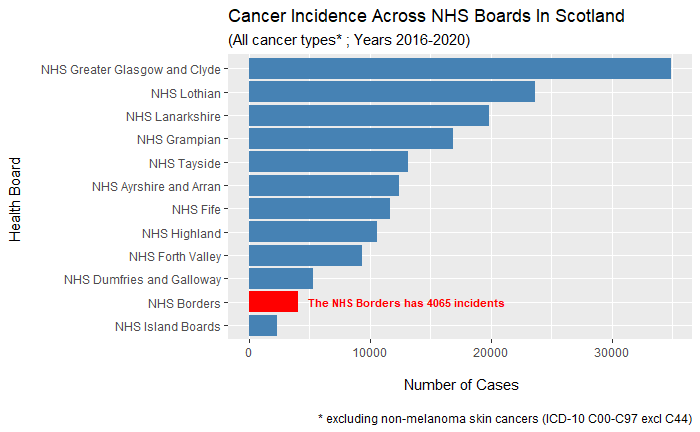

```r
incidence_5_year_summary %>%
  filter(cancer_site == "All cancer types", sex == "All") %>%
  mutate(label_text = ifelse(hb_name == "NHS Borders",
                             "The NHS Borders has 4065 incidents", NA)) %>%
  select(hb_name, incidences_all_ages, label_text) %>%
  ggplot() +
  aes(
    x = reorder(hb_name, incidences_all_ages),
    y = incidences_all_ages,
    fill = reorder(hb_name, incidences_all_ages) == "NHS Borders"
  ) +
  geom_col() +
  scale_fill_manual(values = c('steelblue', 'red'), guide = "none") +
  coord_flip() +
  geom_text(aes(label = label_text), fontface = "bold",
           color = "red", size = 3, hjust = -0.05) +
  ggtitle(
    "Cancer Incidence Across NHS Boards In Scotland",
    subtitle =  "(All cancer types* ; Years 2016-2020)"
  ) +
  labs(x = "Health Board \n ",
       y = "\n Number of Cases",
       caption = "\n * excluding non-melanoma skin cancers (ICD-10 C00-C97 excl C44)"
  )
```

```r
incidence_5_year_summary %>%
  filter(cancer_site == "All cancer types", sex == "All", hb_name == "NHS Borders") %>%
  select(cancer_site, sex, year, incidences_all_ages)
```

| cancer_site | sex | year | incidences_all_ages |
| --- | --- | --- | --- |
| All cancer types | All | 2016-2020 | 4065 |

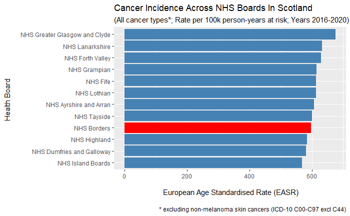

```r
incidence_5_year_summary %>%
  filter(cancer_site == "All cancer types", sex == "All") %>%
  select(hb_name, easr) %>%
  ggplot() +
  aes(
    x = reorder(hb_name, easr),
    y = easr,
    fill = reorder(hb_name, easr) == "NHS Borders"
  ) +
  geom_col() +
  scale_fill_manual(values = c('steelblue', 'red'), guide = "none") +
  coord_flip() +
  ggtitle(
    "Cancer Incidence Across NHS Boards In Scotland",
    subtitle =  "(All cancer types*; Rate per 100k person-years at risk; Years 2016-2020)"
  ) +
  labs(x = "Health Board \n ",
       y = "\n European Age Standardised Rate (EASR)",
       caption = "\n * excluding non-melanoma skin cancers (ICD-10 C00-C97 excl C44)"
  )
```

## Cancer Incident trend

Trend plot of all cancer types

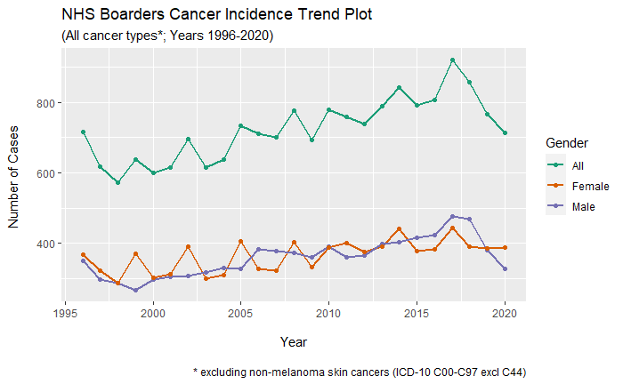

```r
incidence %>%
  filter(cancer_site == "All cancer types", hb_name == "NHS Borders", ) %>%
  select(cancer_site, sex, year, incidences_all_ages) %>%
  ggplot() +
  aes(x = year, y = incidences_all_ages, group = sex, colour = sex) +
  geom_line(size = 0.75) +
  geom_point(size = 1.5) +
  scale_colour_brewer(palette = "Dark2") +
  ggtitle(
    "NHS Boarders Cancer Incidence Trend Plot",
    subtitle =  "(All cancer types*; Years 1996-2020)"
  ) +
  labs(x = "\nYear",
       y = "Number of Cases \n",
       caption = "\n * excluding non-melanoma skin cancers (ICD-10 C00-C97 excl C44)",
       color = "Gender")
```

```r
NA
```

## 5 Year Summary

Top 5 most common cancer types across all ages for 2016-2020:

```r
incidence_5_year_summary %>%
  filter(sex == "All", cancer_site != "All cancer types", hb_name == "NHS Borders") %>%
  select(cancer_site, incidences_all_ages) %>%
  # slice_max(incidences_all_ages, n = 5, with_ties = TRUE)
  arrange(desc(incidences_all_ages)) %>%
  summarise(sum_inc = sum(incidences_all_ages))
```

| sum_inc |
| --- |
| 7216 |

```r
incidence_5_year_summary %>%
  filter(cancer_site == "All cancer types", hb_name == "NHS Borders") %>%
  select(sex, cancer_site, incidences_all_ages) %>%
  # slice_max(incidences_all_ages, n = 5, with_ties = TRUE)
  arrange(desc(incidences_all_ages))
```

| sex | cancer_site | incidences_all_ages |
| --- | --- | --- |
| All | All cancer types | 4065 |
| Male | All cancer types | 2074 |
| Female | All cancer types | 1991 |

[figure not shown]

```r
incidence_5_year_summary %>%
  filter(
    sex == "All",
    cancer_site != "All cancer types",
    hb_name == "NHS Borders"
  ) %>%
  select(cancer_site, incidences_all_ages) %>%
  slice_max(incidences_all_ages, n = 5, with_ties = TRUE) %>%
  ggplot() +
  aes(x = reorder(cancer_site, incidences_all_ages), y = incidences_all_ages) +
  geom_col(fill = "steelblue") +
  geom_text(
    aes(label = incidences_all_ages),
    fontface = "bold",
    color = "white",
    size = 3,
    hjust = 1.25
  ) +
  coord_flip() +
  ggtitle(
    "Top 5 Cancer Types Across All Ages",
    subtitle =  "(Years 1996-2020)"
  ) +
  labs(x = "Year \n", y = "\n Number of Cases")
```

```r
# incidence_5_year_summary %>%
#   filter(
#     sex == "All",
#     # cancer_site == "All cancer types",
#     hb_name == "NHS Borders"
#   ) %>%
#   select(cancer_site, incidences_all_ages) %>%
```

Top 5 most common cancer types for males across all ages for 2016-2020:

```r
incidence_5_year_summary %>%
  filter(cancer_site != "All cancer types", sex == "Male", hb_name == "NHS Borders") %>%
  select(cancer_site, incidences_all_ages) %>%
  slice_max(incidences_all_ages, n = 5, with_ties = TRUE)
```

| cancer_site | incidences_all_ages |
| --- | --- |
| Non-melanoma skin cancer | 962 |
| Basal cell carcinoma of the skin | 563 |
| Prostate | 555 |
| Squamous cell carcinoma of the skin | 384 |
| Trachea, bronchus and lung | 278 |

```r
  # arrange(desc(incidences_all_ages))
```

[figure not shown]

```r
incidence_5_year_summary %>%
  filter(
    cancer_site != "All cancer types",
    sex == "Male",
    hb_name == "NHS Borders"
  ) %>%
  select(cancer_site, incidences_all_ages) %>%
  slice_max(incidences_all_ages, n = 5, with_ties = TRUE) %>%
  ggplot() +
  aes(x = reorder(cancer_site, incidences_all_ages), y = incidences_all_ages) +
  geom_col(fill = "steelblue") +
  geom_text(
    aes(label = incidences_all_ages),
    fontface = "bold",
    color = "white",
    size = 3,
    hjust = 1.5
  ) +
  coord_flip() +
  ggtitle(
    "Top 5 Cancer Types For Males Across All Ages",
    subtitle =  "(Years 1996-2020)"
  ) +
  labs(x = "Year", y = "\n Number of Cases") +
  ylim(c(0, 1000))
```

Top 5 most common cancer types for females across all ages for 2016-2020:

```r
incidence_5_year_summary %>%
  filter(
    cancer_site != "All cancer types",
    sex == "Female",
    hb_name == "NHS Borders"
    ) %>%
  select(cancer_site, incidences_all_ages) %>%
  slice_max(incidences_all_ages, n = 5, with_ties = TRUE)
```

| cancer_site | incidences_all_ages |
| --- | --- |
| Breast | 534 |
| Non-melanoma skin cancer | 534 |
| Basal cell carcinoma of the skin | 405 |
| Trachea, bronchus and lung | 294 |
| Colorectal cancer | 261 |

```r
  # arrange(desc(incidences_all_ages))
```

[figure not shown]

```r
incidence_5_year_summary %>%
  filter(
    cancer_site != "All cancer types",
    sex == "Female",
    hb_name == "NHS Borders"
  ) %>%
  select(cancer_site, incidences_all_ages) %>%
  slice_max(incidences_all_ages, n = 5, with_ties = TRUE) %>%
  ggplot() +
  aes(x = reorder(cancer_site, incidences_all_ages), y = incidences_all_ages) +
  geom_col(fill = "steelblue") +
  geom_text(
    aes(label = incidences_all_ages),
    fontface = "bold",
    color = "white",
    size = 3,
    hjust = 1.5
  ) +
  coord_flip() +
  ggtitle(
    "Top 5 Cancer Types For Females Across All Ages",
    subtitle =  "(Years 1996-2020)"
  ) +
  labs(x = "Year \n", y = "\n Number of Cases")
```

Most affected age group from cancer for 2016-2020:

```r
# Change tibble format to long
incidence_5_year_summary_longer <- incidence_5_year_summary %>%
  filter(
    cancer_site == "All cancer types",
    hb_name == "NHS Borders"
  ) %>%
  select(cancer_site, sex, starts_with("incidences_age")) %>%
  pivot_longer(
    -c(cancer_site, sex),
    names_to = "incidences_age",
    values_to = "cancer_incidences"
  ) %>%
  separate(
    incidences_age,
    c("extra_column","age_group"),
    sep ="incidences_age_*"
  ) %>%
  select(-extra_column)


# Get age group values in presentable format and place in correct order
incidence_5_year_summary_longer <- incidence_5_year_summary_longer %>%
  mutate(age_group = str_replace(age_group, "to", "-")) %>%
  mutate(age_group = str_replace(age_group, "under", "<")) %>%
  mutate(age_group = str_replace(age_group, "and_over", "+")) %>%
  mutate(
    age_group = factor(
      age_group,
      levels = c("<5", "5-9", "10-14", "15-19", "20-24", "25-29", "30-34",
                 "35-39", "40-44", "45-49", "50-54", "55-59", "60-64", "65-69",
                 "70-74","75-79", "80-84", "85+" )
    )
  )



incidence_5_year_summary_longer %>%
  group_by(age_group) %>%
  select(age_group, sex, cancer_incidences) %>%
  arrange(desc(age_group))
```

| age_group | sex | cancer_incidences |
| --- | --- | --- |
| 85+ | All | 450 |
| 85+ | Male | 210 |
| 85+ | Female | 240 |
| 80-84 | All | 466 |
| 80-84 | Male | 255 |
| 80-84 | Female | 211 |
| 75-79 | All | 573 |
| 75-79 | Male | 303 |
| 75-79 | Female | 270 |
| 70-74 | All | 701 |

[output cut: 44 more lines]

[figure not shown]

```r
incidence_5_year_summary_longer %>%
  filter(sex == "All") %>%
  group_by(age_group) %>%
  select(age_group, sex, cancer_incidences) %>%
  ggplot() +
  aes(x = age_group, y = cancer_incidences) +
  geom_col(fill = "steelblue") +
  geom_text(
    aes(label = cancer_incidences),
    fontface = "bold",
    color = "black",
    size = 3,
    vjust = -0.5
  ) +
  theme(axis.text.x = element_text(angle = 30, vjust = 0.5)) +
  ggtitle(
    "Cancer Incidents By Age",
    subtitle =  "(All cancer types*; Years 1996-2020)"
  ) +
  labs(x = "\n Age Group",
       y = "Number of Cases \n",
       caption = "\n * excluding non-melanoma skin cancers (ICD-10 C00-C97 excl C44)"
  )
```

[figure not shown]

```r
incidence_5_year_summary_longer %>%
  filter(sex != "All") %>%
  group_by(age_group) %>%
  select(age_group, sex, cancer_incidences) %>%
  ggplot() +
  aes(x = age_group, y = cancer_incidences, fill = sex) +
  geom_col(position = "dodge") +
  scale_fill_manual(values=c("blue", "steelblue")) +
  theme(axis.text.x = element_text(angle = 30, vjust = 0.5)) +
  ggtitle(
    "Cancer Incidents By Age and Gender",
    subtitle =  "(All cancer types*; Years 1996-2020)"
  ) +
  labs(x = "\n Age Group",
       y = "Number of Cases \n",
       fill = "Gender",
       caption = "\n * excluding non-melanoma skin cancers (ICD-10 C00-C97 excl C44)"
  )
```

[figure not shown]

```r
incidence_5_year_summary_longer %>%
  group_by(age_group) %>%
  select(age_group, sex, cancer_incidences) %>%
  ggplot() +
  aes(x = age_group, y = cancer_incidences, fill = sex) +
  geom_col(position = "dodge") +
  facet_wrap(~sex) +
  scale_fill_manual(values=c("steelblue", "blue", "darkgreen")) +
  theme(axis.text.x = element_text(angle = 30, vjust = 0.5)) +
  ggtitle(
    "Cancer Incidents By Age and Gender",
    subtitle =  "(Years 1996-2020)"
  ) +
  labs(x = "\n Age Group", y = "Number of Cases \n", fill = "Sex")
```

# Junk

Trend plot of Non-melanoma skin cancer (most common cancer types across all ages for 2016-2020)

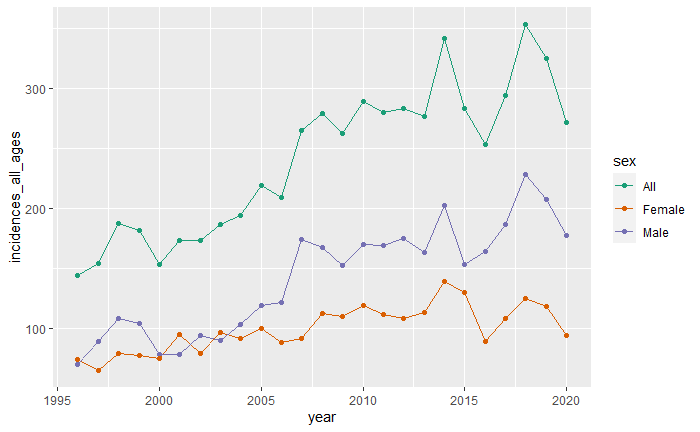

```r
incidence %>%
  filter(cancer_site == "Non-melanoma skin cancer", hb_name == "NHS Borders") %>%
  select(cancer_site, sex, year, incidences_all_ages) %>%
  ggplot() +
  aes(x = year, y = incidences_all_ages, group = sex, colour = sex) +
  geom_line() +
  geom_point() +
  scale_colour_brewer(palette = "Dark2")
```

```r
NA
NA
```

Top 5 least common cancer types across all ages for 2016-2020:

```r
incidence_5_year_summary %>%
  filter(sex == "All", cancer_site != "All cancer types", hb_name == "NHS Borders") %>%
  select(cancer_site, incidences_all_ages) %>%
  slice_min(incidences_all_ages, n = 5, with_ties = TRUE)
```

| cancer_site | incidences_all_ages |
| --- | --- |
| Bone and articular cartilage | 5 |
| Acute lymphoblastic leukaemia | 8 |
| Salivary glands | 9 |
| Connective tissue | 13 |
| Larynx | 13 |
| Acute myeloid leukaemia | 13 |

```r
  # arrange(desc(incidences_all_ages))
```

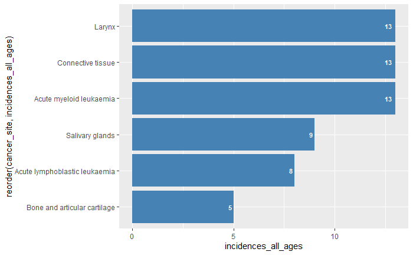

```r
incidence_5_year_summary %>%
  filter(sex == "All", cancer_site != "All cancer types", hb_name == "NHS Borders") %>%
  select(cancer_site, incidences_all_ages) %>%
  slice_min(incidences_all_ages, n = 5, with_ties = TRUE) %>%
  ggplot() +
  aes(x = reorder(cancer_site, incidences_all_ages), y = incidences_all_ages) +
  geom_col(fill = "steelblue") +
  geom_text(aes(label = incidences_all_ages), fontface = "bold", color = "white", size = 3, hjust = 1.5)+
  coord_flip()
```